# Penalized Regression Approaches

Kaan Bilgin

1/1/2021

# 1.Introduction

In this report, the codes and results is summarised for the tasks in Homework 3.

```r
library(tidyverse)
library(data.table)
library(CVXR)
library(kableExtra)
library(glmnet)
```

```r
data_path = "C:/Users/Kaan/Documents/GitHub/fall20-kaanblgn/files/HW3/Usage_Data.csv"
data = fread(data_path)
colnames(data)<-c("Date","Hour","Consumption")
data$Consumption = gsub(".","",data$Consumption,fixed = T)
data$Consumption = as.numeric(gsub(",",".",data$Consumption,fixed = T))
data_clean = data%>%transmute(Date=lubridate::dmy(Date),Hour = as.numeric(substr(Hour,1,2)),Consumption)

summary(data_clean)
```

```
##       Date                 Hour        Consumption
##  Min.   :2016-06-01   Min.   : 0.00   Min.   :15333
##  1st Qu.:2017-07-17   1st Qu.: 5.75   1st Qu.:29014
##  Median :2018-09-01   Median :11.50   Median :33196
##  Mean   :2018-09-01   Mean   :11.50   Mean   :32997
##  3rd Qu.:2019-10-17   3rd Qu.:17.25   3rd Qu.:36650
##  Max.   :2020-12-01   Max.   :23.00   Max.   :47062
```

```r
data_clean%>%filter(Consumption==0)
```

```
## Empty data.table (0 rows and 3 cols): Date,Hour,Consumption
```

```r
data_clean%>%group_by(Date)%>%summarise(n=length(unique(Hour)))%>%ungroup()%>%filter(n!=24)
```

```
## # A tibble: 0 x 2
## # ... with 2 variables: Date <date>, n <int>
```

```r
# make NA 2016-03-27 because of save light time.
setDT(data_clean)
data_clean[Date=="2016-03-27",Hour:=c(0:23)]
data_clean[Date=="2016-03-27",Consumption:=NA]

summary(data_clean)
```

```
##       Date                 Hour        Consumption
##  Min.   :2016-06-01   Min.   : 0.00   Min.   :15333
##  1st Qu.:2017-07-17   1st Qu.: 5.75   1st Qu.:29014
##  Median :2018-09-01   Median :11.50   Median :33196
##  Mean   :2018-09-01   Mean   :11.50   Mean   :32997
##  3rd Qu.:2019-10-17   3rd Qu.:17.25   3rd Qu.:36650
##  Max.   :2020-12-01   Max.   :23.00   Max.   :47062
```

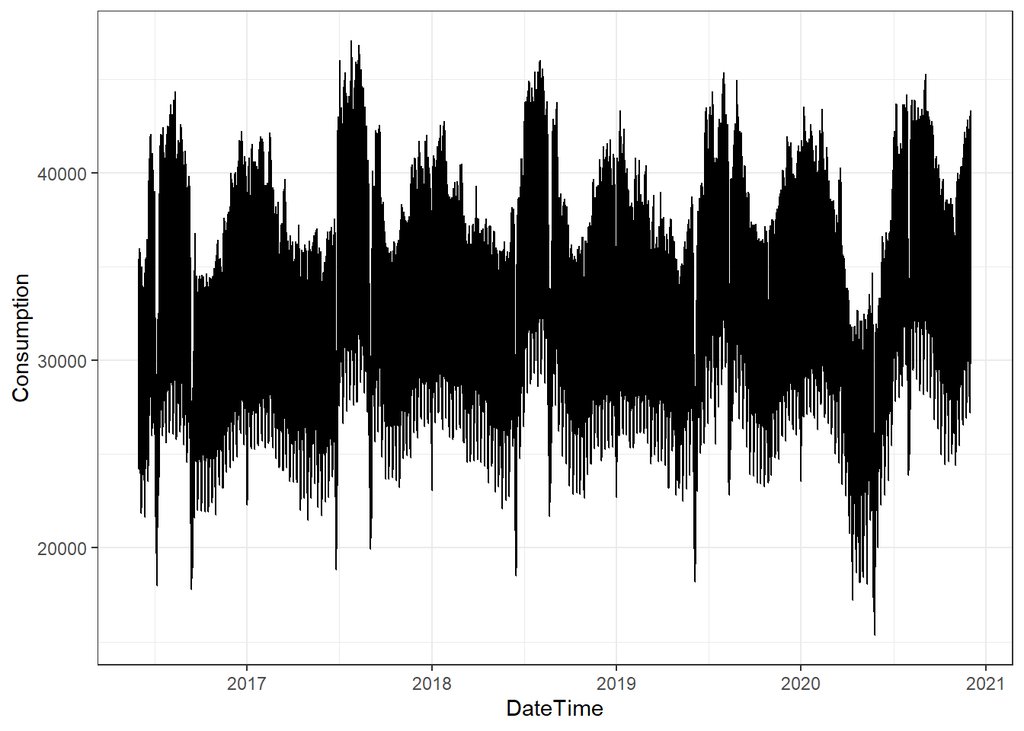

```r
ggplot(data_clean)+geom_line(aes(x=lubridate::as_datetime(Date)+lubridate::hours(Hour),y=Consumption))+
  theme_bw()+labs(x="DateTime")
```

# 2.Tasks

## a) Naive Approache

In this part we will analyze the result of naive prediction of lag48 and lag168. For all tasks, we use until 2020-10-31 as train period and the rest as test period.

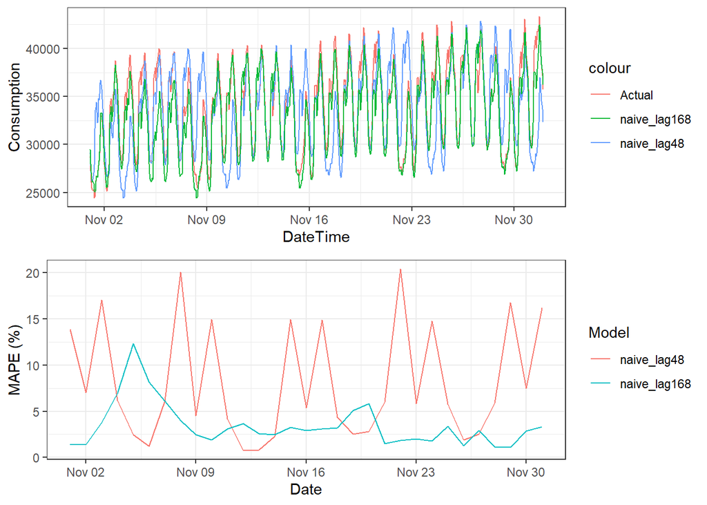

```r
test_start = lubridate::as_date("2020-11-01")

naive_pred = data_clean%>%arrange(Date,Hour)%>%mutate(naive_lag48=lag(Consumption,48),
                                         naive_lag168=lag(Consumption,168))%>%filter(Date>=test_start)

naive_final = melt(naive_pred,1:3,variable.name="Model",value.name="Prediction")

naive_mape = naive_final%>%group_by(Date,Model)%>%summarise(Mape=mean(abs(Prediction-Consumption)/Consumption))%>%ungroup()

naive_mape_general = naive_mape%>%group_by(Model)%>%summarise(TestStart=min(Date),TestEnd=max(Date),
                                                               NDay=length(unique(Date)),
                                                               Min_Mape=min(Mape),Q25_Mape=quantile(Mape,0.25),
                                                               Median_Mape=median(Mape),Avg_Mape=mean(Mape),
                                                               Q75_Mape=quantile(Mape,0.75),Max_Mape=max(Mape))%>%ungroup()

p1 = ggplot(naive_final)+geom_line(aes(x=lubridate::as_datetime(Date)+lubridate::hours(Hour),y=Consumption,col="Actual"))+
  geom_line(aes(x=lubridate::as_datetime(Date)+lubridate::hours(Hour),y=Prediction,col=Model))+
  theme_bw()+labs(x="DateTime")

p2 = ggplot(naive_mape)+geom_line(aes(x=Date,y=Mape*100,col=Model))+
  theme_bw()+labs(x="Date",y="MAPE (%)")

gridExtra::grid.arrange(p1,p2,nrow=2)
```

```r
naive_mape_general %>%
kbl() %>%
  kable_classic(full_width = F, html_font = "Cambria")
```

| Model | TestStart | TestEnd | NDay | Min_Mape | Q25_Mape | Median_Mape | Avg_Mape | Q75_Mape | Max_Mape |
| --- | --- | --- | --- | --- | --- | --- | --- | --- | --- |
| naive_lag48 | 2020-11-01 | 2020-12-01 | 31 | 0.0074837 | 0.0268541 | 0.0587395 | 0.0806031 | 0.1483346 | 0.2038553 |
| naive_lag168 | 2020-11-01 | 2020-12-01 | 31 | 0.0112858 | 0.0187917 | 0.0292953 | 0.0344919 | 0.0370700 | 0.1234274 |

We can observe that lag168 gives better performance compared to lag48. This may be because of the different characteristics of weekdays. Weekends behave different than working days.

## b) Linear Regression Models Using Lag Consumption as Feature

In this part, we build linear regression model for long format including all hours.

```r
lm_long_data = data_clean%>%arrange(Date,Hour)%>%mutate(lag48=lag(Consumption,48),
                                                      lag168=lag(Consumption,168))
lm_long_train = lm_long_data%>%filter(Date<test_start)%>%na.omit()
lm_long_test = lm_long_data%>%filter(Date>=test_start)
lm_long_fit = lm(data = lm_long_train,Consumption~lag48+lag168)
summary(lm_long_fit)
```

```
##
## Call:
## lm(formula = Consumption ~ lag48 + lag168, data = lm_long_train)
##
## Residuals:
##      Min       1Q   Median       3Q      Max
## -17108.2  -1007.5      2.4   1049.2  15986.2
##
## Coefficients:
##              Estimate Std. Error t value Pr(>|t|)
## (Intercept) 1.688e+03  9.046e+01   18.66   <2e-16 ***
## lag48       3.174e-01  3.282e-03   96.71   <2e-16 ***
## lag168      6.316e-01  3.280e-03  192.56   <2e-16 ***
## ---
## Signif. codes:  0 '***' 0.001 '**' 0.01 '*' 0.05 '.' 0.1 ' ' 1
##
## Residual standard error: 2458 on 38565 degrees of freedom
## Multiple R-squared:  0.7641, Adjusted R-squared:  0.764
## F-statistic: 6.244e+04 on 2 and 38565 DF,  p-value: < 2.2e-16
```

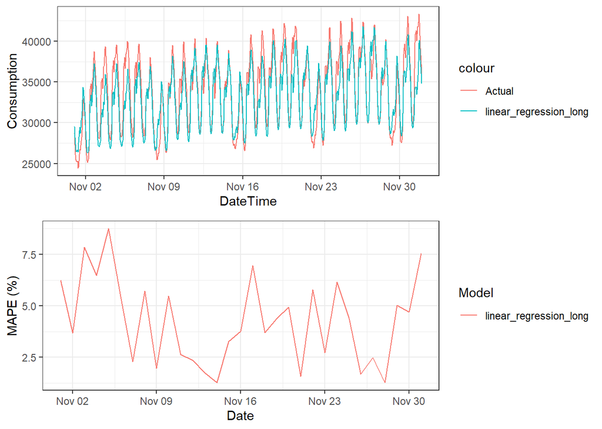

```r
lm_long_test$linear_regression_long <- predict(lm_long_fit,lm_long_test)

lm_long_final = melt(lm_long_test%>%select(Date,Hour,Consumption,linear_regression_long),1:3,variable.name="Model",value.name="Prediction")

lm_long_mape = lm_long_final%>%group_by(Date,Model)%>%summarise(Mape=mean(abs(Prediction-Consumption)/Consumption))%>%ungroup()

lm_long_mape_general = lm_long_mape%>%group_by(Model)%>%summarise(TestStart=min(Date),TestEnd=max(Date),
                                                              NDay=length(unique(Date)),
                                                              Min_Mape=min(Mape),Q25_Mape=quantile(Mape,0.25),
                                                              Median_Mape=median(Mape),Avg_Mape=mean(Mape),
                                                              Q75_Mape=quantile(Mape,0.75),Max_Mape=max(Mape))%>%ungroup()

p1 = ggplot(lm_long_final)+geom_line(aes(x=lubridate::as_datetime(Date)+lubridate::hours(Hour),y=Consumption,col="Actual"))+
  geom_line(aes(x=lubridate::as_datetime(Date)+lubridate::hours(Hour),y=Prediction,col=Model))+
  theme_bw()+labs(x="DateTime")

p2 = ggplot(lm_long_mape)+geom_line(aes(x=Date,y=Mape*100,col=Model))+
  theme_bw()+labs(x="Date",y="MAPE (%)")

gridExtra::grid.arrange(p1,p2,nrow=2)
```

```r
lm_long_mape_general %>%
kbl() %>%
  kable_classic(full_width = F, html_font = "Cambria")
```

| Model | TestStart | TestEnd | NDay | Min_Mape | Q25_Mape | Median_Mape | Avg_Mape | Q75_Mape | Max_Mape |
| --- | --- | --- | --- | --- | --- | --- | --- | --- | --- |
| linear_regression_long | 2020-11-01 | 2020-12-01 | 31 | 0.0126746 | 0.0241427 | 0.0438865 | 0.0426889 | 0.0574908 | 0.0874807 |

We observe that both lag48 and lag168 are significant in regression. Overall performance is between two naive methods.

## c) Seaonality Effect Inspection

In this part, because of hourly seasonality, we have build linear regression for each our then aggregated results for overall performance.

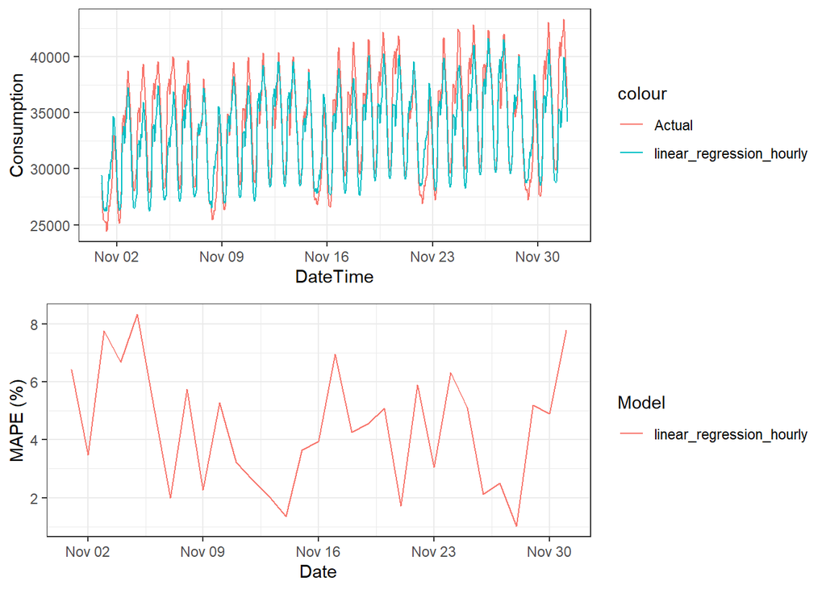

```r
lm_hourly_test=tibble()
for(hour in 0:23){
  temp_train = lm_long_data%>%filter(Date<test_start)%>%filter(Hour==hour)%>%na.omit()
  temp_test = lm_long_data%>%filter(Date>=test_start)%>%filter(Hour==hour)
  temp_fit = lm(data = temp_train,Consumption~lag48+lag168)
  temp_test$linear_regression_hourly <- predict(temp_fit,temp_test)
  lm_hourly_test=rbind(lm_hourly_test,temp_test)
}
lm_hourly_final = melt(lm_hourly_test%>%select(Date,Hour,Consumption,linear_regression_hourly),1:3,variable.name="Model",value.name="Prediction")

lm_hourly_mape = lm_hourly_final%>%group_by(Date,Model)%>%summarise(Mape=mean(abs(Prediction-Consumption)/Consumption))%>%ungroup()

lm_hourly_mape_general = lm_hourly_mape%>%group_by(Model)%>%summarise(TestStart=min(Date),TestEnd=max(Date),
                                                                  NDay=length(unique(Date)),
                                                                  Min_Mape=min(Mape),Q25_Mape=quantile(Mape,0.25),
                                                                  Median_Mape=median(Mape),Avg_Mape=mean(Mape),
                                                                  Q75_Mape=quantile(Mape,0.75),Max_Mape=max(Mape))%>%ungroup()

p1 = ggplot(lm_hourly_final)+geom_line(aes(x=lubridate::as_datetime(Date)+lubridate::hours(Hour),y=Consumption,col="Actual"))+
  geom_line(aes(x=lubridate::as_datetime(Date)+lubridate::hours(Hour),y=Prediction,col=Model))+
  theme_bw()+labs(x="DateTime")

p2 = ggplot(lm_hourly_mape)+geom_line(aes(x=Date,y=Mape*100,col=Model))+
  theme_bw()+labs(x="Date",y="MAPE (%)")

gridExtra::grid.arrange(p1,p2,nrow=2)
```

```r
lm_hourly_mape_general %>%
kbl() %>%
  kable_classic(full_width = F, html_font = "Cambria")
```

| Model | TestStart | TestEnd | NDay | Min_Mape | Q25_Mape | Median_Mape | Avg_Mape | Q75_Mape | Max_Mape |
| --- | --- | --- | --- | --- | --- | --- | --- | --- | --- |
| linear_regression_hourly | 2020-11-01 | 2020-12-01 | 31 | 0.0100957 | 0.025549 | 0.0454722 | 0.0439749 | 0.0582282 | 0.0832713 |

According to performance results, we can derive that modelling each hour separately does not improve performance significantly for linear regression.

## d) Lasso Regression

In this part, we will apply lasso regression with L1 penalty by using cv.glmnet. For cv.glmnet, we will use alpha = 1 parameter to apply L1 because alpha=0 gives ridge and alpha =1 gives lasso regression. Also, we have modeled each hour separately and for each hour, we use the wide lag48 and lag168 feature set.

Also, we will analyze coefficients and lambda values of models.

[figure not shown]

[figure not shown]

[figure not shown]

[figure not shown]

[figure not shown]

[figure not shown]

```r
feature_matrix = dcast(as.data.table(lm_long_data%>%na.omit()),Date~Hour,value.var=c("lag48","lag168"))
train_matrix = feature_matrix%>%filter(Date<test_start)
test_matrix = feature_matrix%>%filter(Date>=test_start)

train_dates = train_matrix$Date
train_feature = as.matrix(train_matrix%>%select(-Date))
test_feature = as.matrix(test_matrix%>%select(-Date))

par(mfrow=c(4,2))
full_summary_glmnet = tibble()
glmnet_lasso_hourly_final = tibble()
for(hour in 0:23){
  train_target = (lm_long_data%>%filter(Hour==hour&Date%in%train_dates))$Consumption
  set.seed(1)
  temp_fit = cv.glmnet(x = train_feature,y=train_target,nfolds = 10,alpha=1)
  plot(temp_fit)
  plot(temp_fit$glmnet.fit)

  temp_pred = data.table(Date=test_matrix$Date,Hour=hour,glmnet_lasso_hourly_lambdamin=predict(temp_fit,test_feature,s=c("lambda.min"))[,1],
             glmnet_lasso_hourly_lambda1se=predict(temp_fit,test_feature,s=c("lambda.1se"))[,1])

  glmnet_lasso_hourly_final = rbind(glmnet_lasso_hourly_final,temp_pred)

  full_summary_glmnet=full_summary_glmnet%>%
    bind_rows(data.table(variable=names(as.matrix(coef(temp_fit))[,1]),coefficent=as.matrix(coef(temp_fit))[,1],
       model=paste0("model_for_hour_",hour),lambda1se=temp_fit$lambda.1se,lambdamin=temp_fit$lambda.min)
  )
}
```

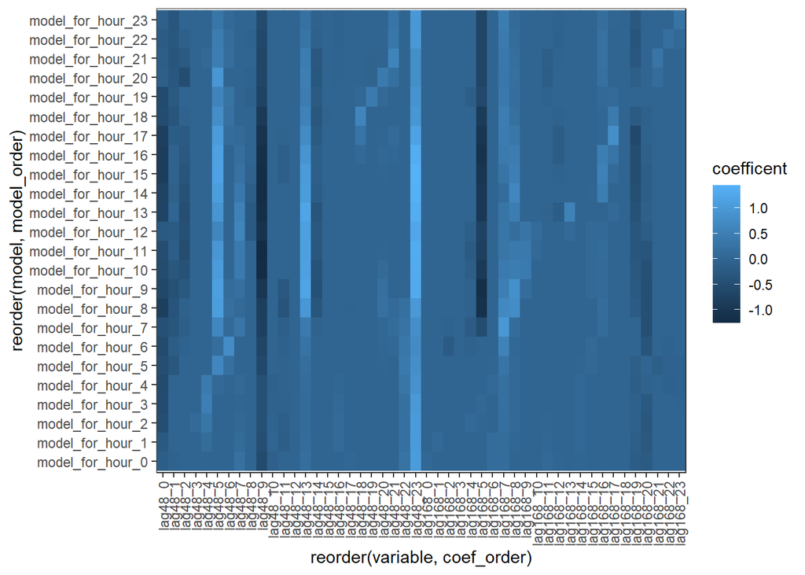

```r
par(mfrow=c(1,1))

full_summary_glmnet=full_summary_glmnet%>%group_by(model)%>%mutate(coef_order=row_number())%>%ungroup()%>%
  group_by(variable)%>%mutate(model_order=row_number())%>%ungroup()
ggplot(full_summary_glmnet%>%filter(variable!="(Intercept)"))+geom_tile(aes(x=reorder(variable,coef_order),y=reorder(model,model_order),fill=coefficent))+
  theme_bw()+ theme(axis.text.x = element_text(angle = 90, vjust = 0.5, hjust=1))
```

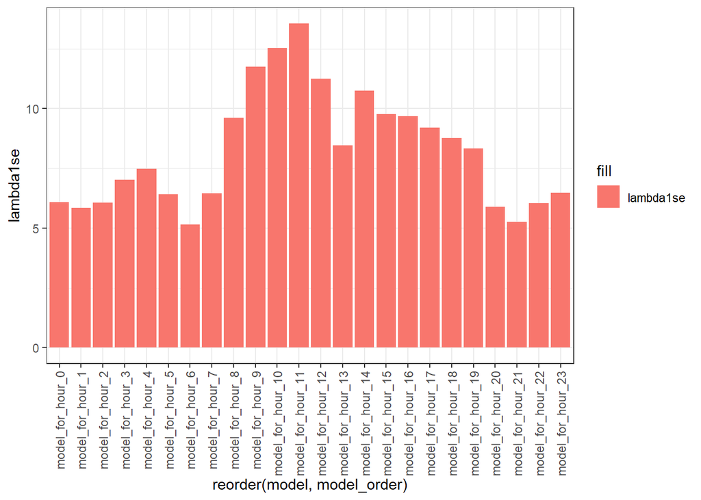

```r
ggplot(full_summary_glmnet%>%select(model,lambda1se,lambdamin,model_order)%>%unique())+
  geom_bar(aes(x=reorder(model,model_order),y=lambda1se,fill="lambda1se"),stat = "identity")+theme_bw()+ theme(axis.text.x = element_text(angle = 90, vjust = 0.5, hjust=1))
```

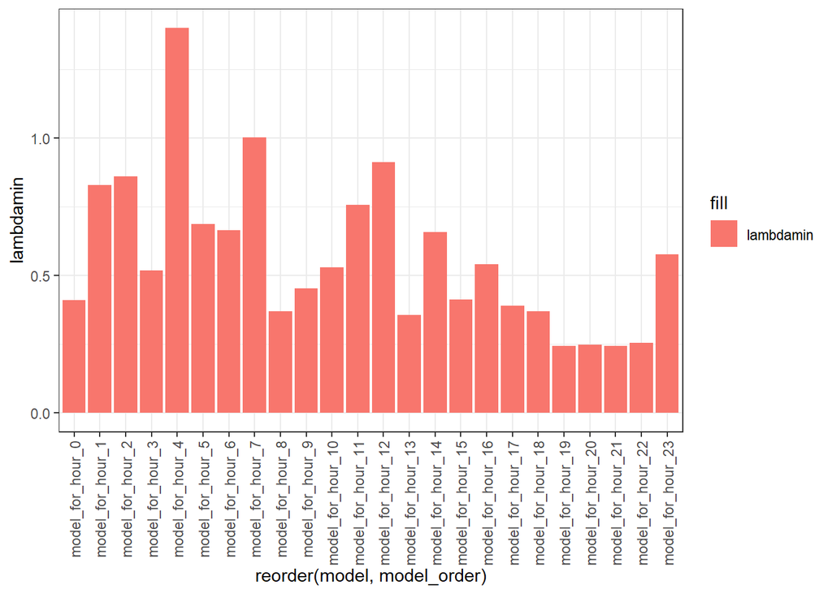

```r
ggplot(full_summary_glmnet%>%select(model,lambda1se,lambdamin,model_order)%>%unique())+
  geom_bar(aes(x=reorder(model,model_order),y=lambdamin,fill="lambdamin"),stat = "identity")+theme_bw()+ theme(axis.text.x = element_text(angle = 90, vjust = 0.5, hjust=1))
```

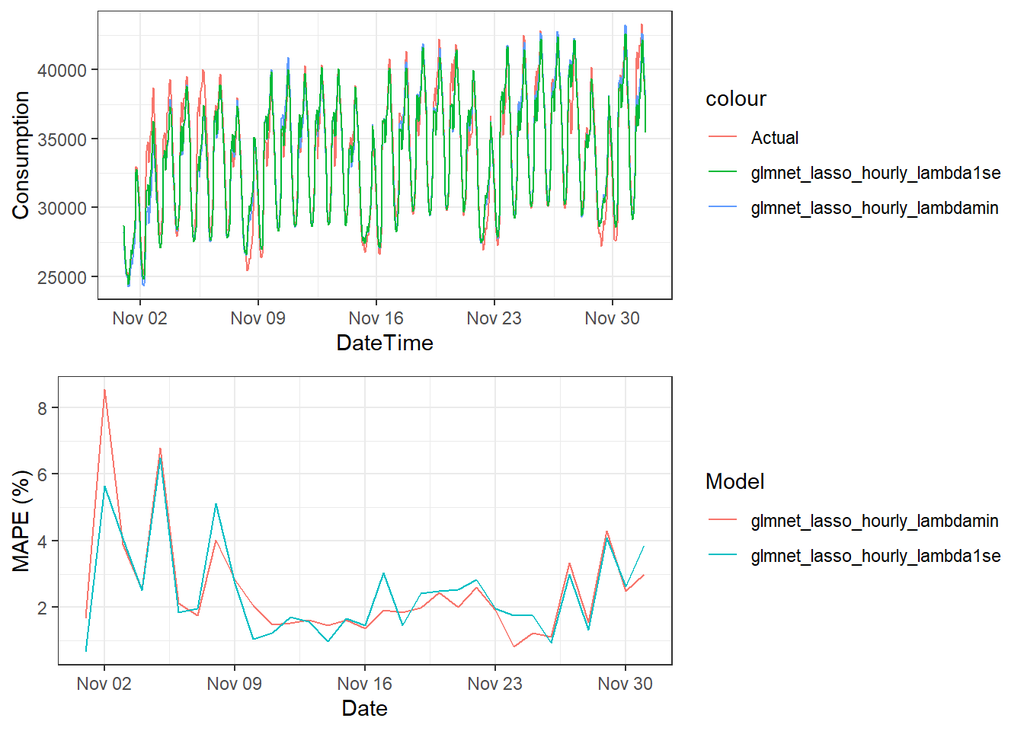

```r
glmnet_lasso_hourly_final=melt(glmnet_lasso_hourly_final,1:2,variable.name="Model",value.name="Prediction")%>%left_join(lm_long_data%>%select(Date,Hour,Consumption))

glmnet_lasso_hourly_mape = glmnet_lasso_hourly_final%>%group_by(Date,Model)%>%summarise(Mape=mean(abs(Prediction-Consumption)/Consumption))%>%ungroup()

glmnet_lasso_hourly_mape_general = glmnet_lasso_hourly_mape%>%group_by(Model)%>%summarise(TestStart=min(Date),TestEnd=max(Date),
                                                                      NDay=length(unique(Date)),
                                                                      Min_Mape=min(Mape),Q25_Mape=quantile(Mape,0.25),
                                                                      Median_Mape=median(Mape),Avg_Mape=mean(Mape),
                                                                      Q75_Mape=quantile(Mape,0.75),Max_Mape=max(Mape))%>%ungroup()

p1 = ggplot(glmnet_lasso_hourly_final)+geom_line(aes(x=lubridate::as_datetime(Date)+lubridate::hours(Hour),y=Consumption,col="Actual"))+
  geom_line(aes(x=lubridate::as_datetime(Date)+lubridate::hours(Hour),y=Prediction,col=Model))+
  theme_bw()+labs(x="DateTime")

p2 = ggplot(glmnet_lasso_hourly_mape)+geom_line(aes(x=Date,y=Mape*100,col=Model))+
  theme_bw()+labs(x="Date",y="MAPE (%)")

gridExtra::grid.arrange(p1,p2,nrow=2)
```

```r
glmnet_lasso_hourly_mape_general %>%
kbl() %>%
  kable_classic(full_width = F, html_font = "Cambria")
```

| Model | TestStart | TestEnd | NDay | Min_Mape | Q25_Mape | Median_Mape | Avg_Mape | Q75_Mape | Max_Mape |
| --- | --- | --- | --- | --- | --- | --- | --- | --- | --- |
| glmnet_lasso_hourly_lambdamin | 2020-11-01 | 2020-12-01 | 31 | 0.0080772 | 0.0157965 | 0.0198978 | 0.0250843 | 0.0271663 | 0.0853878 |
| glmnet_lasso_hourly_lambda1se | 2020-11-01 | 2020-12-01 | 31 | 0.0065151 | 0.0151754 | 0.0195723 | 0.0247309 | 0.0290797 | 0.0649528 |

We observe that;

- The models of consecutive hours are similar in terms of the coefficients of features. This is expected because consecutive hours are higly correlated so, it is possible to have similar coefficients for feature set.
- Also, lambda1se values are similar for consecutive models.
- Some features takes positive coefficent for all models.
- Lambdamin and lambda1se gives close results. So, lambda1se is more efficient to use.
- Performance improves significantly compared to previous tasks.